# EDA - In-Class Lab Exercise (Day 1) - Deepak

|  | Inclass - Lab (Day 1) |
| --- | --- |

### About the dataset (Adult Income Data)

The dataset contains information about the individuals' age, gender, and several attributes affecting the income of a person.  
Attribute information:

**age:** Age of an individual

**workclass:** Working class of the individual

**fnlwgt:** Weights based on the demographic characteristics

**education:** Highest education of the individual

**education.num:** Education encoded with unique numbers

**marital.status:** Marital status of the individual

**occupation:** Occupation of the individual

**relationship:** Relation of the individual in the family

**race:** Race of the individual

**sex:** Gender of the individual (0 = Male, 1 = Female)

**capital.gain:** Gain amount of the individual

**capital.loss:** Loss amount of the individual

**hours.per.week:** Working hours per week

**native.country:** The native country of the individual

**income:** Income of the individual

## Table of Content

1. **Understand the Dataset**
2. **Measures of Central Tendency**
3. **Measures of Dispersion**
4. **Distribution of the Data**
5. **Skewness and kurtosis**
6. **Correlation**

**Import the required libraries**

```python
import numpy as np
import pandas as pd
```

**Load the adults income dataset and print first five observations**

```python
df=pd.read_csv('adult_income.csv')
print(df)
```

```
       age workclass  fnlwgt     education  education.num      marital.status  \
0       90         ?   77053       HS-grad              9             Widowed
1       82   Private  132870       HS-grad              9             Widowed
2       66         ?  186061  Some-college             10             Widowed
3       54   Private  140359       7th-8th              4            Divorced
4       41   Private  264663  Some-college             10           Separated
...    ...       ...     ...           ...            ...                 ...
32556   22   Private  310152  Some-college             10       Never-married
32557   27   Private  257302    Assoc-acdm             12  Married-civ-spouse
32558   40   Private  154374       HS-grad              9  Married-civ-spouse
32559   58   Private  151910       HS-grad              9             Widowed
32560   22   Private  201490       HS-grad              9       Never-married

              occupation   relationship   race  sex  capital.gain  \
0                      ?  Not-in-family  White    1             0
```

[output cut: 25 more lines]

### Let's begin with some hands-on practice exercises

## 1. Understand the Dataset

|  | **1. Find out the numerical and categorical variables in the data. If any variable is wrongly identified, do the needful** |
| --- | --- |

```python
df.select_dtypes('object')
```

|  | workclass | education | marital.status | occupation | relationship | race | native.country | income |
| --- | --- | --- | --- | --- | --- | --- | --- | --- |
| 0 | ? | HS-grad | Widowed | ? | Not-in-family | White | United-States | <=50K |
| 1 | Private | HS-grad | Widowed | Exec-managerial | Not-in-family | White | United-States | <=50K |
| 2 | ? | Some-college | Widowed | ? | Unmarried | Black | United-States | <=50K |
| 3 | Private | 7th-8th | Divorced | Machine-op-inspct | Unmarried | White | United-States | <=50K |
| 4 | Private | Some-college | Separated | Prof-specialty | Own-child | White | United-States | <=50K |
| ... | ... | ... | ... | ... | ... | ... | ... | ... |
| 32556 | Private | Some-college | Never-married | Protective-serv | Not-in-family | White | United-States | <=50K |
| 32557 | Private | Assoc-acdm | Married-civ-spouse | Tech-support | Wife | White | United-States | <=50K |
| 32558 | Private | HS-grad | Married-civ-spouse | Machine-op-inspct | Husband | White | United-States | >50K |
| 32559 | Private | HS-grad | Widowed | Adm-clerical | Unmarried | White | United-States | <=50K |
| 32560 | Private | HS-grad | Never-married | Adm-clerical | Own-child | White | United-States | <=50K |

32561 rows × 8 columns

```python
df.select_dtypes('int64')
```

|  | age | fnlwgt | education.num | sex | capital.gain | capital.loss | hours.per.week |
| --- | --- | --- | --- | --- | --- | --- | --- |
| 0 | 90 | 77053 | 9 | 1 | 0 | 4356 | 40 |
| 1 | 82 | 132870 | 9 | 1 | 0 | 4356 | 18 |
| 2 | 66 | 186061 | 10 | 1 | 0 | 4356 | 40 |
| 3 | 54 | 140359 | 4 | 1 | 0 | 3900 | 40 |
| 4 | 41 | 264663 | 10 | 1 | 0 | 3900 | 40 |
| ... | ... | ... | ... | ... | ... | ... | ... |
| 32556 | 22 | 310152 | 10 | 0 | 0 | 0 | 40 |
| 32557 | 27 | 257302 | 12 | 1 | 0 | 0 | 38 |
| 32558 | 40 | 154374 | 9 | 0 | 0 | 0 | 40 |
| 32559 | 58 | 151910 | 9 | 1 | 0 | 0 | 40 |
| 32560 | 22 | 201490 | 9 | 0 | 0 | 0 | 20 |

32561 rows × 7 columns

```python
df.info()
```

```
<class 'pandas.core.frame.DataFrame'>
RangeIndex: 32561 entries, 0 to 32560
Data columns (total 15 columns):
 #   Column          Non-Null Count  Dtype
---  ------          --------------  -----
 0   age             32561 non-null  int64
 1   workclass       32561 non-null  object
 2   fnlwgt          32561 non-null  int64
 3   education       32561 non-null  object
 4   education.num   32561 non-null  int64
 5   marital.status  32561 non-null  object
 6   occupation      32561 non-null  object
 7   relationship    32561 non-null  object
 8   race            32561 non-null  object
 9   sex             32561 non-null  int64
 10  capital.gain    32561 non-null  int64
 11  capital.loss    32561 non-null  int64
 12  hours.per.week  32561 non-null  int64
 13  native.country  32561 non-null  object
 14  income          32561 non-null  object
dtypes: int64(7), object(8)
memory usage: 3.7+ MB
```

```python
df=df.astype({'sex': object})
df.info()
```

```
<class 'pandas.core.frame.DataFrame'>
RangeIndex: 32561 entries, 0 to 32560
Data columns (total 15 columns):
 #   Column          Non-Null Count  Dtype
---  ------          --------------  -----
 0   age             32561 non-null  int64
 1   workclass       32561 non-null  object
 2   fnlwgt          32561 non-null  int64
 3   education       32561 non-null  object
 4   education.num   32561 non-null  int64
 5   marital.status  32561 non-null  object
 6   occupation      32561 non-null  object
 7   relationship    32561 non-null  object
 8   race            32561 non-null  object
 9   sex             32561 non-null  object
 10  capital.gain    32561 non-null  int64
 11  capital.loss    32561 non-null  int64
 12  hours.per.week  32561 non-null  int64
 13  native.country  32561 non-null  object
 14  income          32561 non-null  object
dtypes: int64(6), object(9)
memory usage: 3.7+ MB
```

## 2. Measures of Central Tendency

|  | **2. What is the average age of males and females in the data?** |
| --- | --- |

```python
df.groupby(by='sex')['age'].mean()
```

```
sex
0    39.433547
1    36.858230
Name: age, dtype: float64
```

|  | **3. What is the value under which 95% of the capital gain would lie?** |
| --- | --- |

```python
df['capital.gain'].quantile(0.95)
```

```
5013.0
```

|  | **4. Identify the qualification of most of the individuals** |
| --- | --- |

```python
df
```

|  | age | workclass | fnlwgt | education | education.num | marital.status | occupation | relationship | race | sex | capital.gain | capital.loss | hours.per.week | native.country | income |
| --- | --- | --- | --- | --- | --- | --- | --- | --- | --- | --- | --- | --- | --- | --- | --- |
| 0 | 90 | ? | 77053 | HS-grad | 9 | Widowed | ? | Not-in-family | White | 1 | 0 | 4356 | 40 | United-States | <=50K |
| 1 | 82 | Private | 132870 | HS-grad | 9 | Widowed | Exec-managerial | Not-in-family | White | 1 | 0 | 4356 | 18 | United-States | <=50K |
| 2 | 66 | ? | 186061 | Some-college | 10 | Widowed | ? | Unmarried | Black | 1 | 0 | 4356 | 40 | United-States | <=50K |
| 3 | 54 | Private | 140359 | 7th-8th | 4 | Divorced | Machine-op-inspct | Unmarried | White | 1 | 0 | 3900 | 40 | United-States | <=50K |
| 4 | 41 | Private | 264663 | Some-college | 10 | Separated | Prof-specialty | Own-child | White | 1 | 0 | 3900 | 40 | United-States | <=50K |
| ... | ... | ... | ... | ... | ... | ... | ... | ... | ... | ... | ... | ... | ... | ... | ... |
| 32556 | 22 | Private | 310152 | Some-college | 10 | Never-married | Protective-serv | Not-in-family | White | 0 | 0 | 0 | 40 | United-States | <=50K |
| 32557 | 27 | Private | 257302 | Assoc-acdm | 12 | Married-civ-spouse | Tech-support | Wife | White | 1 | 0 | 0 | 38 | United-States | <=50K |
| 32558 | 40 | Private | 154374 | HS-grad | 9 | Married-civ-spouse | Machine-op-inspct | Husband | White | 0 | 0 | 0 | 40 | United-States | >50K |
| 32559 | 58 | Private | 151910 | HS-grad | 9 | Widowed | Adm-clerical | Unmarried | White | 1 | 0 | 0 | 40 | United-States | <=50K |
| 32560 | 22 | Private | 201490 | HS-grad | 9 | Never-married | Adm-clerical | Own-child | White | 0 | 0 | 0 | 20 | United-States | <=50K |

32561 rows × 15 columns

```python
df['education'].mode()
```

```
0    HS-grad
dtype: object
```

|  | **5. Find the middle most observation of age for different working class** |
| --- | --- |

```python
df.groupby(by='workclass')['age'].median()
```

```
workclass
?                   35
Federal-gov         43
Local-gov           41
Never-worked        18
Private             35
Self-emp-inc        45
Self-emp-not-inc    44
State-gov           39
Without-pay         57
Name: age, dtype: int64
```

|  | **6. Compare the mean and trimmed mean of capital gain and comment on the presence of outliers** |
| --- | --- |

```python
df['capital.gain'].mean()
```

```
1077.6488437087312
```

```python
import scipy as sp
from scipy import stats
sp.stats.trim_mean(df['capital.gain'],0.01)  # for 1 percentage from both sides.
```

```
493.7085331077058
```

|  | **7. What is the percentage of the Asian-Pac-Islander race people in the data?** |
| --- | --- |

```python
df
```

|  | age | workclass | fnlwgt | education | education.num | marital.status | occupation | relationship | race | sex | capital.gain | capital.loss | hours.per.week | native.country | income |
| --- | --- | --- | --- | --- | --- | --- | --- | --- | --- | --- | --- | --- | --- | --- | --- |
| 0 | 90 | ? | 77053 | HS-grad | 9 | Widowed | ? | Not-in-family | White | 1 | 0 | 4356 | 40 | United-States | <=50K |
| 1 | 82 | Private | 132870 | HS-grad | 9 | Widowed | Exec-managerial | Not-in-family | White | 1 | 0 | 4356 | 18 | United-States | <=50K |
| 2 | 66 | ? | 186061 | Some-college | 10 | Widowed | ? | Unmarried | Black | 1 | 0 | 4356 | 40 | United-States | <=50K |
| 3 | 54 | Private | 140359 | 7th-8th | 4 | Divorced | Machine-op-inspct | Unmarried | White | 1 | 0 | 3900 | 40 | United-States | <=50K |
| 4 | 41 | Private | 264663 | Some-college | 10 | Separated | Prof-specialty | Own-child | White | 1 | 0 | 3900 | 40 | United-States | <=50K |
| ... | ... | ... | ... | ... | ... | ... | ... | ... | ... | ... | ... | ... | ... | ... | ... |
| 32556 | 22 | Private | 310152 | Some-college | 10 | Never-married | Protective-serv | Not-in-family | White | 0 | 0 | 0 | 40 | United-States | <=50K |
| 32557 | 27 | Private | 257302 | Assoc-acdm | 12 | Married-civ-spouse | Tech-support | Wife | White | 1 | 0 | 0 | 38 | United-States | <=50K |
| 32558 | 40 | Private | 154374 | HS-grad | 9 | Married-civ-spouse | Machine-op-inspct | Husband | White | 0 | 0 | 0 | 40 | United-States | >50K |
| 32559 | 58 | Private | 151910 | HS-grad | 9 | Widowed | Adm-clerical | Unmarried | White | 1 | 0 | 0 | 40 | United-States | <=50K |
| 32560 | 22 | Private | 201490 | HS-grad | 9 | Never-married | Adm-clerical | Own-child | White | 0 | 0 | 0 | 20 | United-States | <=50K |

32561 rows × 15 columns

```python
df1=df[df.race=='Asian-Pac-Islander'].race.count()*100/df.race.count()
print(round(df1,2))
```

```
3.19
```

## 3. Measures of Dispersion

|  | **8. Which occupation has more variability in the working hours** |
| --- | --- |

```python
df
```

|  | age | workclass | fnlwgt | education | education.num | marital.status | occupation | relationship | race | sex | capital.gain | capital.loss | hours.per.week | native.country | income |
| --- | --- | --- | --- | --- | --- | --- | --- | --- | --- | --- | --- | --- | --- | --- | --- |
| 0 | 90 | ? | 77053 | HS-grad | 9 | Widowed | ? | Not-in-family | White | 1 | 0 | 4356 | 40 | United-States | <=50K |
| 1 | 82 | Private | 132870 | HS-grad | 9 | Widowed | Exec-managerial | Not-in-family | White | 1 | 0 | 4356 | 18 | United-States | <=50K |
| 2 | 66 | ? | 186061 | Some-college | 10 | Widowed | ? | Unmarried | Black | 1 | 0 | 4356 | 40 | United-States | <=50K |
| 3 | 54 | Private | 140359 | 7th-8th | 4 | Divorced | Machine-op-inspct | Unmarried | White | 1 | 0 | 3900 | 40 | United-States | <=50K |
| 4 | 41 | Private | 264663 | Some-college | 10 | Separated | Prof-specialty | Own-child | White | 1 | 0 | 3900 | 40 | United-States | <=50K |
| ... | ... | ... | ... | ... | ... | ... | ... | ... | ... | ... | ... | ... | ... | ... | ... |
| 32556 | 22 | Private | 310152 | Some-college | 10 | Never-married | Protective-serv | Not-in-family | White | 0 | 0 | 0 | 40 | United-States | <=50K |
| 32557 | 27 | Private | 257302 | Assoc-acdm | 12 | Married-civ-spouse | Tech-support | Wife | White | 1 | 0 | 0 | 38 | United-States | <=50K |
| 32558 | 40 | Private | 154374 | HS-grad | 9 | Married-civ-spouse | Machine-op-inspct | Husband | White | 0 | 0 | 0 | 40 | United-States | >50K |
| 32559 | 58 | Private | 151910 | HS-grad | 9 | Widowed | Adm-clerical | Unmarried | White | 1 | 0 | 0 | 40 | United-States | <=50K |
| 32560 | 22 | Private | 201490 | HS-grad | 9 | Never-married | Adm-clerical | Own-child | White | 0 | 0 | 0 | 20 | United-States | <=50K |

32561 rows × 15 columns

```python
a1=df.groupby('occupation')['hours.per.week'].var()
print(a1[a1.values==a1.max()])
```

```
occupation
Farming-fishing    299.987814
Name: hours.per.week, dtype: float64
```

```python
a1
```

```
occupation
?                    225.317543
Adm-clerical          91.964888
Armed-Forces         198.000000
Craft-repair          81.939394
Exec-managerial      123.412395
Farming-fishing      299.987814
Handlers-cleaners    111.946104
Machine-op-inspct     57.648955
Other-service        161.442544
Priv-house-serv      261.939597
Prof-specialty       157.159186
Protective-serv      152.072728
Sales                175.202547
Tech-support         112.001859
Transport-moving     161.833503
Name: hours.per.week, dtype: float64
```

|  | **9. What is the range of the middle 50% of working hours per week?** |
| --- | --- |

```python
r=df['hours.per.week'].quantile(0.75)-df['hours.per.week'].quantile(0.25)
print(r)
```

```
5.0
```

|  | **10. Are there any variables which can be excluded from further analysis based on their variability?** |
| --- | --- |

```python
df.std()
## Yes. The parameter 'sex' has the minimun and very low value of standard deviation.
## So, we can exclude that from the analysis as there is minimum or almost zero deviation in that parameter.
```

```
age                   13.640433
fnlwgt            105549.977697
education.num          2.572720
sex                    0.470506
capital.gain        7385.292085
capital.loss         402.960219
hours.per.week        12.358681
dtype: float64
```

|  | **11. Find the percentage of variation in work hours for each workclass. Give an appropriate interpretation** |
| --- | --- |

```python
#Coefficient of variation=(standard Deviation/Mod of Mean)*100
a=df.groupby('workclass')['hours.per.week'].std()
b=abs(df.groupby('workclass')['hours.per.week'].mean())

percentage=(a/b)*100
percentage
```

```
workclass
?                   46.711116
Federal-gov         21.360037
Local-gov           26.283120
Never-worked              NaN
Private             27.954085
Self-emp-inc        28.473900
Self-emp-not-inc    37.537713
State-gov           29.968071
Without-pay         53.059084
Name: hours.per.week, dtype: float64
```

## 4. Distribution of the Data

|  | **12. Define a function to plot the categories of the variable and find the category with highest frequency** |
| --- | --- |

```python
#dist plot
import seaborn as sns
import matplotlib.pyplot as plt
df['education'].value_counts().head(1)
```

```
HS-grad    10501
Name: education, dtype: int64
```

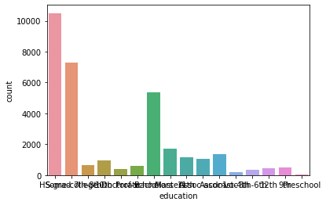

```python
f=plt.figure(figsize=(10,8), dpi=100)
sns.countplot(df['education'])
```

```python
def function(feature):
    print('Max entry is of',df[feature].value_counts().head(1))
    plt.figure(figsize=(18,8))
    sns.countplot(df[feature])
    plt.show()
```

[output not shown]

[figure not shown]

```python
function('education')
```

|  | **13. Is there any variable which is normally distributed?** |
| --- | --- |

[figure not shown]

```python
sns.pairplot(df,kind='kde')
```

|  | **14. Identify the working class for most of the population in the data** |
| --- | --- |

```python
w1=df['workclass'].value_counts()
print(w1[w1.values==w1.max()])
```

```
Private    22696
Name: workclass, dtype: int64
```

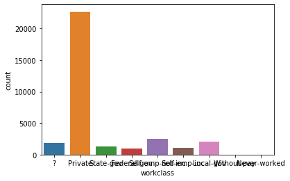

```python
import seaborn as sns
sns.countplot(df['workclass'])
```

|  | **15. For how much time are most of the individuals working per week?** |
| --- | --- |

```python
df['hours.per.week'].mode()
```

```
0    40
dtype: int64
```

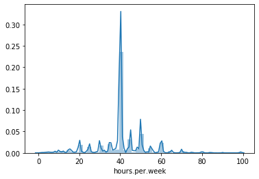

```python
sns.distplot(df['hours.per.week'])
```

## 5. Skewness and kurtosis

|  | **16. Is there any negatively skewed feature. Support your answer with a metric and the plot** |
| --- | --- |

```python
df.skew()
```

```
age                0.558743
fnlwgt             1.446980
education.num     -0.311676
sex                0.719293
capital.gain      11.953848
capital.loss       4.594629
hours.per.week     0.222241
dtype: float64
```

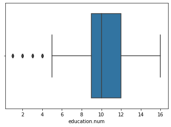

```python
sns.boxplot(df['education.num'])
```

|  | **17. Find the kurtosis of all the variables, and give appropriate interpretation** |
| --- | --- |

```python
df.kurt()
```

```
age                -0.166127
fnlwgt              6.218811
education.num       0.623444
sex                -1.482709
capital.gain      154.799438
capital.loss       20.376802
hours.per.week      2.916782
dtype: float64
```

|  | **18. Identify the presence of extreme values in age using visualization techniques** |
| --- | --- |

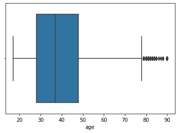

```python
sns.boxplot(df.age)
```

## 6. Correlation

|  | **19. Is there any effect of age on the working hours of a person?** |
| --- | --- |

```python
df.corr()[['age','hours.per.week']]
```

|  | age | hours.per.week |
| --- | --- | --- |
| age | 1.000000 | 0.069311 |
| fnlwgt | -0.076646 | -0.019033 |
| education.num | 0.036527 | 0.148544 |
| capital.gain | 0.077674 | 0.078409 |
| capital.loss | 0.057775 | 0.054314 |
| hours.per.week | 0.069311 | 1.000000 |

[output not shown]

```python
arr=np.random.randint(1,100,36).reshape(6,6)
print(arr)
```

```
[[ 7 19 90 29  6 39]
 [87 19 18 27 79 19]
 [36 95 78 16 75 50]
 [66 25 12  8 13 63]
 [20 54 25 20 77 79]
 [50 18 89 19 78 39]]
```

```python
mask_var=np.zeros_like(df.corr())
mask_var
```

```
array([[0., 0., 0., 0., 0., 0.],
       [0., 0., 0., 0., 0., 0.],
       [0., 0., 0., 0., 0., 0.],
       [0., 0., 0., 0., 0., 0.],
       [0., 0., 0., 0., 0., 0.],
       [0., 0., 0., 0., 0., 0.]])
```

```python
np.tril_indices_from(mask_var, k=-1)
```

```
(array([1, 2, 2, 3, 3, 3, 4, 4, 4, 4, 5, 5, 5, 5, 5]),
 array([0, 0, 1, 0, 1, 2, 0, 1, 2, 3, 0, 1, 2, 3, 4]))
```

```python
mask_var[np.tril_indices_from(mask_var, k=-1)]= True
mask_var
```

```
array([[0., 0., 0., 0., 0., 0.],
       [1., 0., 0., 0., 0., 0.],
       [1., 1., 0., 0., 0., 0.],
       [1., 1., 1., 0., 0., 0.],
       [1., 1., 1., 1., 0., 0.],
       [1., 1., 1., 1., 1., 0.]])
```

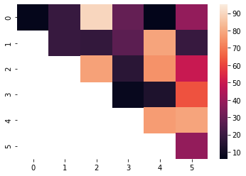

```python
sns.heatmap(arr,mask=mask_var)
plt.show()
```